# Third Week: Exploratory Data Analysis

LaLiga Analysis

benyamin jami al ahmadi 94105282

2018-02-28 01:19:11

# تمرین سری سوم: از لالیگا تا لیگ برتر

> با استفاده از داده های لیگ دسته اول اسپانیا به سوالات زیر پاسخ دهید. از هر دو ابزار ggplot2 و highcharter برای این کار تصویرسازی استفاده نمایید.

۱. تعداد قهرمانی های تیم ها در تاریخ لالیگا را استخراج کرده و نمودار ستونی آنها را رسم کنید.

```r
soc %>% select(Season,home,visitor,hgoal,vgoal) %>%
  bind_rows(select(.,Season,home = visitor,visitor = home,hgoal = vgoal,vgoal = hgoal)) %>%
  mutate(hscore = ifelse(hgoal > vgoal,3,ifelse(hgoal == vgoal,1,0)) , gd = hgoal - vgoal) %>%
  group_by(Season,home) %>% summarise(score = sum(hscore),gd = sum(gd)) %>% group_by(Season) %>%
  filter(score == max(score)) %>% group_by(Season) %>% filter(gd == max(gd)) %>%
  select(Season,team = home,score) -> soc1
soc1 %>% group_by(team) %>% summarise(n= n()) %>% arrange(-n) -> soc12

hchart(soc12,type = 'column',hcaes(x = team,y = n)) %>% hc_add_theme(hc_theme_ffx())
```

[interactive chart not shown]

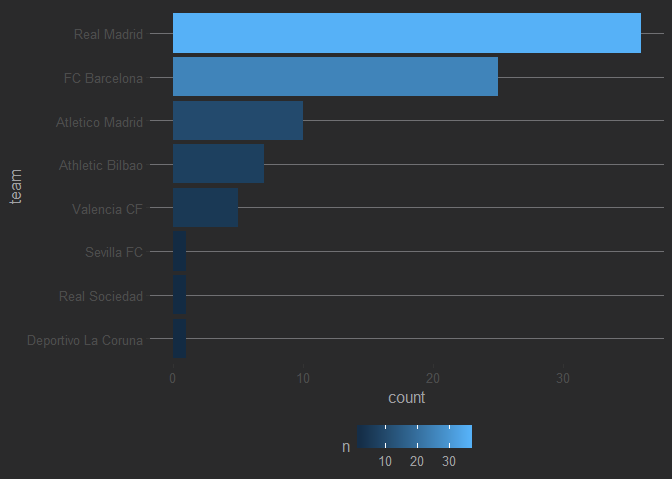

```r
ggplot(soc12,aes(reorder(team,n),n))+geom_bar(aes(fill = n),stat = 'identity')+coord_flip()+ theme_hc(bgcolor = "darkunica") + scale_colour_hc("darkunica") + ylab('count')+xlab('team')
```

۲. کسل کننده ترین لیگ و تیم را بیابید. نمودار ده تیم و ده فصل کسل کننده را رسم کنید.

```r
soc %>% select(Season,home,visitor,hgoal,vgoal) %>%
  bind_rows(select(.,Season,home = visitor,visitor = home,hgoal = vgoal,vgoal = hgoal)) %>%
  group_by(home) %>% summarise(avegoal = sum(hgoal)/n()) %>% arrange(-avegoal) %>%
  filter(row_number()<11) ->soc21

hchart(soc21,type = 'column',hcaes(x = home,y = avegoal)) %>% hc_add_theme(hc_theme_ffx())
```

[interactive chart not shown]

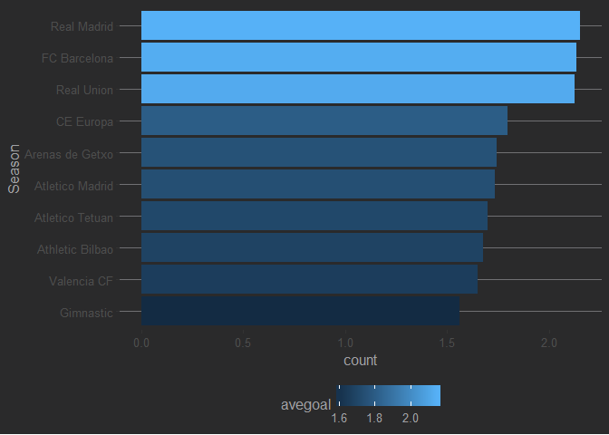

```r
ggplot(soc21,aes(reorder(home,avegoal),avegoal))+geom_bar(aes(fill = avegoal),stat = 'identity')+coord_flip()+ theme_hc(bgcolor = "darkunica") + scale_colour_hc("darkunica") + ylab('count')+xlab('Season')
```

```r
soc %>% group_by(Season) %>% summarise(avegoal = (sum(hgoal) + sum(vgoal))/n()) %>%
  arrange(avegoal) %>% filter(row_number() < 11) ->soc22


hchart(soc22,type = 'column',hcaes(x = Season,y = avegoal)) %>% hc_add_theme(hc_theme_ffx())
```

[interactive chart not shown]

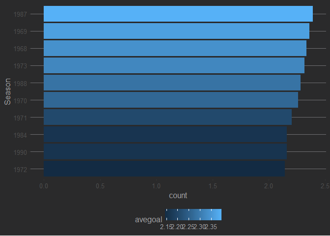

```r
ggplot(soc22,aes(reorder(Season,avegoal),avegoal))+geom_bar(aes(fill = avegoal),stat = 'identity')+coord_flip()+ theme_hc(bgcolor = "darkunica") + scale_colour_hc("darkunica") + ylab('count')+xlab('Season')
```

۳. در چند درصد موارد قهرمان نیم فصل در پایان فصل قهرمان شده است؟

```r
soc %>% group_by(Season) %>% filter(row_number() <= n()/2) %>% select(Season,home,visitor,hgoal,vgoal) %>%
  bind_rows(select(.,Season,home = visitor,visitor = home,hgoal = vgoal,vgoal = hgoal)) %>%
  mutate(hscore = ifelse(hgoal > vgoal,3,ifelse(hgoal == vgoal,1,0)) , gd = hgoal - vgoal) %>%
  group_by(Season,home) %>% summarise(score = sum(hscore),gd = sum(gd), ga = sum(hgoal)) %>%
  group_by(Season) %>% filter(score == max(score)) %>% group_by(Season) %>%
  filter(gd == max(gd)) %>% group_by(Season) %>% filter(ga == max(ga)) %>%
  select(Season,team = home) %>% full_join(select(soc1,Season,team),by='Season') %>%
  ungroup(Season) %>% summarise(sum(team.x == team.y) / n()) %>% as.numeric()
```

```
## [1] 0.5232558
```

۴. در بین سال های ۲۰۰۱ تا ۲۰۱۰ گربه سیاه تیم های بزرگ چه تیم هایی بوده است؟

```r
soc %>% filter(Season > 2000, Season < 2011) %>% select(Season,home,visitor,hgoal,vgoal) %>%
  bind_rows(select(.,Season,home = visitor,visitor = home,hgoal = vgoal,vgoal = hgoal)) -> soc4
soc4 %>% filter(home == "FC Barcelona") %>% group_by(visitor) %>%
  summarise(lost = sum(vgoal > hgoal)) %>% arrange(-lost) %>% head(1) %>% as.character()
```

```
## [1] "Atletico Madrid" "7"
```

```r
soc4 %>% filter(home == "Real Madrid") %>% group_by(visitor) %>%
  summarise(lost = sum(vgoal > hgoal)) %>% arrange(-lost) %>% head(1) %>% as.character()
```

```
## [1] "Deportivo La Coruna" "8"
```

```r
soc4 %>% filter(home == "Valencia CF") %>% group_by(visitor) %>%
  summarise(lost = sum(vgoal > hgoal)) %>% arrange(-lost) %>% head(1) %>% as.character()
```

```
## [1] "Real Madrid" "12"
```

```r
soc4 %>% filter(home == "Atletico Madrid") %>% group_by(visitor) %>%
  summarise(lost = sum(vgoal > hgoal)) %>% arrange(-lost) %>% head(1) %>% as.character()
```

```
## [1] "Real Madrid" "13"
```

```r
soc4 %>% filter(home == "Sevilla FC") %>% group_by(visitor) %>%
  summarise(lost = sum(vgoal > hgoal)) %>% arrange(-lost) %>% head(1) %>% as.character()
```

```
## [1] "FC Barcelona" "13"
```

به ترتیب گربه سیاه بارسلونا،ریال مادرید،والنسیا،اتلتیکو مادرید و سویا

۵. در تاریخ لالیگا کدام تیم رکورددار زودترین قهرمانی است؟ همچنین کدام تیم مقتدرانه ترین قهرمانی را داشته است؟

```r
max = 0
sea = 0
team = 0
for(i in 1:89){
  soc %>% filter(Season == 1927+i) %>% select(Date,home,visitor,hgoal,vgoal) %>%
    bind_rows(select(.,Date,home = visitor,visitor = home,hgoal = vgoal,vgoal = hgoal)) %>%
    mutate(hscore = ifelse(hgoal > vgoal,3,ifelse(hgoal == vgoal,1,0)) , gd = hgoal - vgoal) %>%
    arrange(Date) %>% mutate(week = floor((row_number() - 1) / nrow(distinct(.,home))+1)) -> soc5
  week = as.numeric(soc5[nrow(soc5),8])
  if(i+1927<1936 | i+1927>1938){
    for(j in (week/2):week){
      temp5 <- soc5 %>% filter(week <= j) %>% group_by(home) %>% summarise(score = sum(hscore),ga = sum(hgoal),gd = sum(gd)) %>% arrange(-score,-gd,-ga) %>% mutate(rank = row_number()) %>% arrange(-score)
      if((as.numeric(temp5[1,2]) > as.numeric(temp5[2,2]) + 3 * (week - j)) && week - j > max){
        max = week -j
        sea = 1927+i
        team = as.character(temp5[1,1])
      }
    }
  }
}
as.character(paste(team,' ',sea,' ',max))
```

```
## [1] "Real Madrid   1960   5"
```

```r
maxdif = 0
sea2 = 0
for(i in 1:89){
  soc %>% filter(Season == 1927+i) %>% select(Date,home,visitor,hgoal,vgoal) %>% bind_rows(select(.,Date,home = visitor,visitor = home,hgoal = vgoal,vgoal = hgoal)) %>%
    mutate(hscore = ifelse(hgoal > vgoal,3,ifelse(hgoal == vgoal,1,0)) , gd = hgoal - vgoal) %>% arrange(Date) %>%
    mutate(week = floor((row_number() - 1) / nrow(distinct(.,home))+1)) -> soc5
  if(i+1927<1936 | i+1927>1938){
    temp5 <- soc5 %>% group_by(home) %>% summarise(score = sum(hscore),ga = sum(hgoal),gd = sum(gd)) %>% arrange(-score,-gd,-ga) %>% mutate(rank = row_number()) %>% arrange(-score)
    if((as.numeric(temp5[1,2]) - as.numeric(temp5[2,2]) > maxdif)){
      maxdif = as.numeric(temp5[1,2]) - as.numeric(temp5[2,2])
      sea2 = 1927+i
      team = temp5[1,1]
    }
  }
}
as.character(paste(team,' ',sea2,' ',maxdif))
```

```
## [1] "Real Madrid   1962   21"
```

ریال مادرید با 21 امتیاز اختلاف نسبت به تیم دوم در سال 1962 قهرمان شده.